# [Regression Modeling Appendix](http://mdsr-book.github.io/excerpts/mdsr-regression.pdf) — Modified

Last knit: Saturday, January 20, 2018 - 03:00:45 PM.

# Regression modeling

Regression analysis is a powerful and flexible framework that allows an analyst to model an outcome (the *response variable*) as a function of one or more *explanatory variables* (or predictors). Regression forms the basis of many important statistical models described in Chapters 7 and 8. This appendix provides a brief review of linear and logistic *regression models*, beginning with a single predictor, then extending to multiple predictors.

## A.1 Simple linear regression

Linear regression can help us understand how values of a quantitative (numerical) outcome (or response) are associated with values of a quantitative explanatory (or predictor) variable. This technique is often applied in two ways: to generate predicted values or to make inferences regarding associations in the dataset.

In some disciplines the outcome is called the dependent variable and the predictor the independent variable. We avoid such usage since the words dependent and independent have many meanings in statistics.

A simple linear regression model for an outcome y as a function of a predictor $x$ takes the form:

$$\begin{equation}
y_i = \beta_0 + \beta_1 x_i + \epsilon, \quad\text{ for } i=1, \ldots,n,
\end{equation}$$

where $n$ represents the number of observations (rows) in the data set. For this model, $\beta_0$ is the population parameter corresponding to the *intercept* (i.e., the predicted value when $x = 0$) and $\beta_1$ is the true (population) *slope* coefficient (i.e., the predicted increase in $y$ for a unit increase in $x$). The $\epsilon$’s are the *errors* (these are assumed to be random noise with mean 0).

We almost never know the true values of the population parameters $\beta_0$ and $\beta_1$, but we estimate then using data from our sample. The `lm()` function finds the “best” coefficients $\hat{\beta}_0$ and $\hat{\beta}_1$ where the *fitted values* (or expected values) are given by $\hat{y}_i = \hat{\beta}_0 + \hat{\beta}_1x_i.$ What is left over is captured by the *residuals* $(\hat{\epsilon}_i = y_i - \hat{y}_i).$ The model almost never fits perfectly—if it did there would be no need for a model.

The best fitting regression line is usually determined by a *least squares* criteria that minimizes the sum of the squared residuals. The least squares regression line (defined by the values of $\hat{\beta}_0$ and $\hat{\beta}_1$) is unique.

### A.1.1 Motivating example: Modeling usage of a rail trail

The Pioneer Valley Planning Commission (PVPC) collected data north of Chestnut Street in Florence, Massachusetts for a ninety day period. Data collectors set up a laser sensor that recorded when a rail-trail user passed the data collection station.

```r
library(mdsr)
glimpse(RailTrail)
```

```
Observations: 90
Variables: 10
$ hightemp   <int> 83, 73, 74, 95, 44, 69, 66, 66, 80, 79, 78, 65, 41,...
$ lowtemp    <int> 50, 49, 52, 61, 52, 54, 39, 38, 55, 45, 55, 48, 49,...
$ avgtemp    <dbl> 66.5, 61.0, 63.0, 78.0, 48.0, 61.5, 52.5, 52.0, 67....
$ spring     <int> 0, 0, 1, 0, 1, 1, 1, 1, 0, 0, 0, 1, 1, 0, 0, 1, 0, ...
$ summer     <int> 1, 1, 0, 1, 0, 0, 0, 0, 1, 1, 1, 0, 0, 0, 0, 0, 1, ...
$ fall       <int> 0, 0, 0, 0, 0, 0, 0, 0, 0, 0, 0, 0, 0, 1, 1, 0, 0, ...
$ cloudcover <dbl> 7.6, 6.3, 7.5, 2.6, 10.0, 6.6, 2.4, 0.0, 3.8, 4.1, ...
$ precip     <dbl> 0.00, 0.29, 0.32, 0.00, 0.14, 0.02, 0.00, 0.00, 0.0...
$ volume     <int> 501, 419, 397, 385, 200, 375, 417, 629, 533, 547, 4...
$ weekday    <fctr> 1, 1, 1, 0, 1, 1, 1, 0, 0, 1, 1, 1, 1, 1, 1, 1, 0,...
```

The PVPC wants to understand the relationship between daily ridership (i.e., the number of riders and walkers who use the bike path on any given day) and a collection of explanatory variables, including the temperature, rainfall, cloud cover, and day of the week.

In a simple linear regression model, there is a single quantitative explanatory variable. It seems reasonable that the high temperature for the day (`hightemp`, measured in degrees Fahrenheit) might be related to ridership, so we will explore that first. Figure 1 shows a scatterplot between ridership (`volume`) and high temperature (`hightemp`), with the simple linear regression line overlaid. The fitted coefficients are shown below by providing a formula to the `lm()` function.

```r
mod <- lm(volume ~ hightemp, data = RailTrail)
coef(mod)
```

```
(Intercept)    hightemp
 -17.079281    5.701878
```

The first coefficient is $\hat{\beta}_0,$ the estimated $y$-intercept. The interpretation is that if the high temperature was 0 degrees Fahrenheit, then the estimated ridership would be about -17 riders. This is doubly non-sensical in this context, since it is impossible to have a negative number of riders and this represents a substantial extrapolation to far colder temperatures than are present in the data set (recall the Challenger discussion from Chapter 2). It turns out that the monitoring equipment didn’t work when it got too cold, so values for those days are unavailable.

**Pro Tip**: In this case, it is not appropriate to simply multiply the average number of users on the observed days by the number of days in a year, since cold days that are likely to have fewer trail users are excluded due to instrumentation issues. Such missing data can lead to selection bias.

The second coefficient (the slope) is usually more interesting. This coefficient $(\hat{\beta}_1)$ is interpreted as the predicted increase in trail users for each additional degree in temperature.

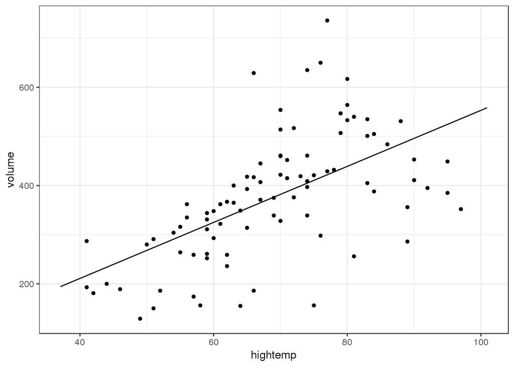

```r
plotModel(mod, system = "ggplot2") +
  theme_bw()
```

**Some behind the scenes munging**

```r
slr <- lm(volume ~ hightemp, data = RailTrail)
coef(slr)
```

```
(Intercept)    hightemp
 -17.079281    5.701878
```

```r
null <- lm(volume ~ 1, data = RailTrail)
coef(null)
```

```
(Intercept)
      375.4
```

```r
library(broom)
ndf1 <- augment(slr)
ndf2 <- augment(null)
ndf2$hightemp <- RailTrail$hightemp
ndf <- bind_rows(ndf1, ndf2) %>%
  mutate(model = rep(c("slr", "null"), each = 90))
```

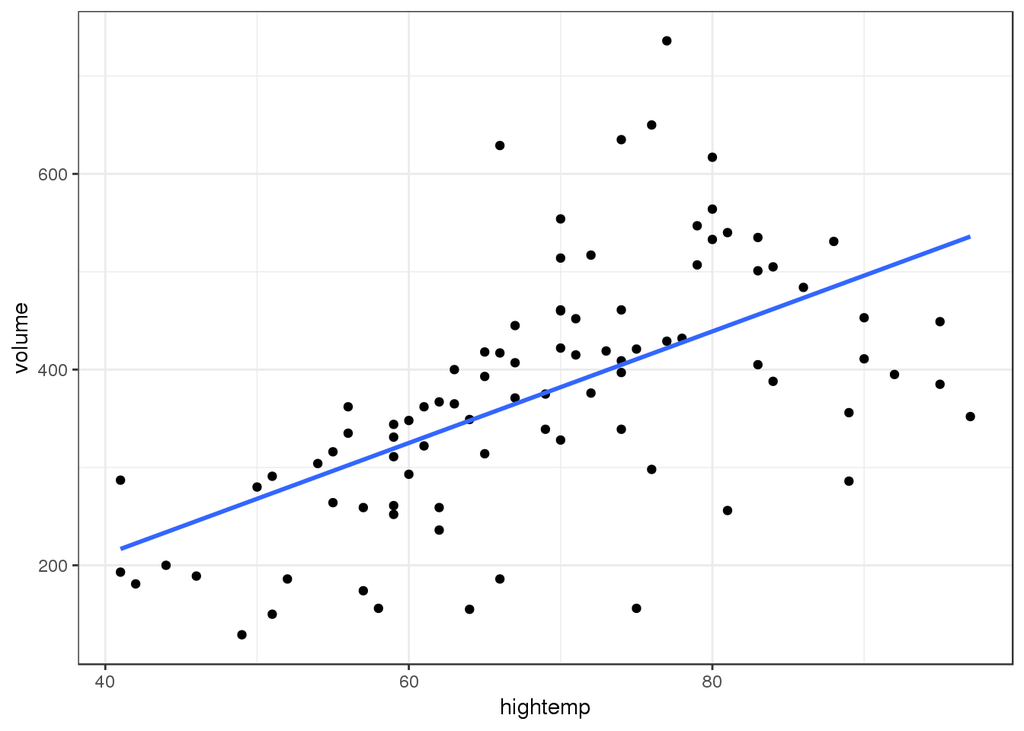

Figure 1: Scatterplot of number of trail crossings as a function of highest daily temperature (in degrees Fahrenheit).

```r
library(ggplot2)
ndf %>%
  filter(model == "slr") %>%
ggplot(aes(x = hightemp, y = volume)) +
  geom_point() +
  geom_smooth(method = "lm", se = FALSE) +
  theme_bw()
```

We expect to see about 5.7 additional riders use the rail trail on a day that is one degree warmer than another day.

### A.1.2 Model visualization

Figure 1 allows us to visualize our model in the data space. How does our model compare to a null model? That is, how do we know that our model is useful?

Obviously, the regression model works better than the null model (that forces the slope to be zero), since it is more flexible. But how much better?

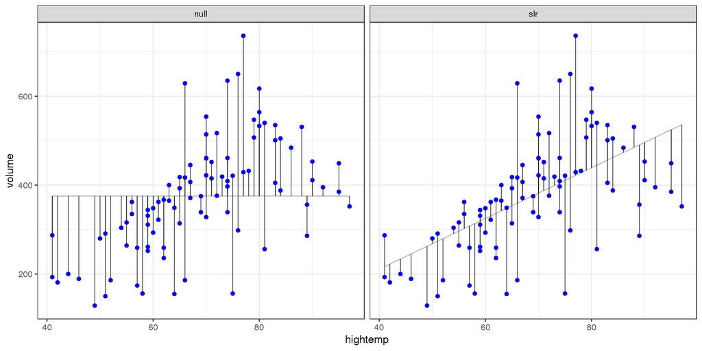

Figure 2: At left, the model based on the overall average high temperature. At right, the simple linear regression model.

### A.1.3 Measuring the strength of fit

The correlation coefficient, $r$, is used to quantify the strength of the linear relationship between two variables. We can quantify the proportion of variation in the response variable ($y$) that is explained by the model in a similar fashion. This quantity is called the coefficient of determination and is denoted $R^2$. It is a common measure of goodness-of-fit for regression models. Like any proportion, $R^2$ is always between 0 and 1. For simple linear regression (one explanatory variable), $R^2 = r^2$. The definition of $R^2$ is given by:

$$\begin{align}
R^2 &= 1 - \frac{\text{SSE}}{\text{SST}} = \frac{\text{SSM}}{\text{SST}}\\
&= 1 - \frac{\sum_{i=1}^n (y_i - \hat{y}_i)^2 }{\sum_{i=1}^n (y_i - \bar{y})^2 }\\
&= 1 - \frac{\text{SSE}}{(n-1)\text{Var}(y)},
\end{align}$$

where SSE is the sum of the squared residuals, SSM is the sum of the squares attributed to the model, and SST is the total sum of the squares. Let’s calculate these values for the rail trail example.

```r
n <- nrow(RailTrail)
SST <- var(~volume, data = RailTrail) * (n - 1)
SSE <- var(residuals(mod)) * (n - 1)
1 - SSE / SST
```

```
[1] 0.33939
```

```r
# Or
rsquared(mod)
```

```
[1] 0.33939
```

A tidyverse approach is:

```r
ndf %>%
  group_by(model) %>%
  summarize(Rsq = 1 - sum((volume - .fitted)^2)/sum((volume - mean(volume))^2))
```

```
# A tibble: 2 x 2
  model   Rsq
  <chr> <dbl>
1 null  0
2 slr   0.339
```

In Figure 2, the null model on the left has an $R^2$ of 0, because $\hat{y}_i = \bar{y}$ for all $i$, and so SSE = SST. On the other hand, the $R^2$ of the regression model on the right is 0.33939. We say that the regression model based on average daily temperature explained about 34% of the variation in daily ridership.

### A.1.4 Categorical explanatory variables

Suppose that instead of using temperature as our explanatory variable for ridership on the rail trail, we only considered whether it was a weekday or not a weekday (e.g., weekend or holiday). The indicator variable `weekday` is *binary* (or dichotomous) in that it only takes on the values 0 and 1. (Such variables are sometimes called *indicator* variables or more pejoratively dummy variables.) This new linear regression model has the form:

$$\begin{equation}
\widehat{\text{volume}} = \hat{\beta}_0 + \hat{\beta}_1 \cdot \text{weekday},
\end{equation}$$

where the coefficients are given below.

```r
modc <- lm(volume ~ weekday, data = RailTrail)
coef(modc)
```

```
(Intercept)    weekday1
  430.71429   -80.29493
```

Note that these coefficients could have been calculated from the mean of the two groups (since the regression model has only two possible predicted values). The average ridership on weekdays is 350.4193548 while the average on non-weekdays is 430.7142857.

```r
RailTrail %>%
  group_by(weekday) %>%
  summarize(MEAN = mean(volume))
```

```
# A tibble: 2 x 2
  weekday  MEAN
  <fctr>  <dbl>
1 0         431
2 1         350
```

```r
# Approach used in book
library(mosaic)
MS <- mean(volume ~ weekday, data = RailTrail)
MS
```

```
       0        1
430.7143 350.4194
```

```r
diff(MS)
```

```
        1
-80.29493
```

In the coefficients listed above, the `weekday1` variable corresponds to rows in which the value of the `weekday` variable was `1` (i.e., weekdays). Because this value is negative, our interpretation is that 80 fewer riders are expected on a weekday as opposed to a weekend or holiday.

To improve the readability of the output we can create a new variable with more mnemonic values.

```r
RailTrail <- RailTrail %>%
  mutate(day = ifelse(weekday == 1, "weekday", "weekend/holiday"))
```

**Pro Tip**: Care was needed to recode the `weekday` variable because it was a `factor`. Avoid the use of factors unless they are needed.

```r
modc1 <- lm(volume ~ day, data = RailTrail)
coef(modc1)
```

```
       (Intercept) dayweekend/holiday
         350.41935           80.29493
```

The model coefficients have changed (although they still provide the same interpretation). By default, the `lm()` function will pick the alphabetically lowest value of the categorical predictor as the *reference group* and create indicators for the other levels (in this case `dayweekend/holiday`). As a result the intercept is now the predicted number of trail crossings on a `weekday`. In either formulation, the interpretation of the model remains the same: On a weekday, 80.2949309 fewer riders are expected than on a weekend or holiday.

## A.2 Multiple regression

Multiple regression is a natural extension of simple linear regression that incorporates multiple explanatory (or predictor) variables. It has the general form:

$$\begin{equation}
y = \beta_0 + \beta_1x_1 + \beta_2x_2 + \cdots + \beta_px_p + \epsilon, \text{ where } \epsilon \sim N(0,\, \sigma_{\epsilon}).
\end{equation}$$

The estimated coefficients (i.e., $\hat{\beta_i}$’s) are now interpreted as ``conditional on’’ the other variables — each $\beta_i$ reflects the *predicted* change in $y$ associated with a one-unit increase in $x_i$, conditional upon the rest of the $x_i$’s. This type of model can help to disentangle more complex relationships between three or more variables. The value of $R^2$ from a multiple regression model has the same interpretation as before: the proportion of variability explained by the model.

**Pro Tip**: Interpreting conditional regression parameters can be challenging. The analyst needs to ensure that comparisons that hold other factors constant do not involve extrapolations beyond the observed data.

### A.2.1 Parallel slopes: Multiple regression with a categorical variable

Consider first the case where $x_2$ is an *indicator* variable that can only be 0 or 1 (e.g., `weekday`). Then,

$$\hat{y} = \hat{\beta}_0 + \hat{\beta}_1x_1 + \hat{\beta}_2x_2.$$

In the case where $x_1$ is quantitative but $x_2$ is an indicator variable, we have:

$$\begin{align*}
\text{For weekends, } \hat{y}|_{x_1, x_2 = 0} &= \hat{\beta}_0 + \hat{\beta}_1x_1\\
\text{For weekdays, } \hat{y}|_{x_1, x_2 = 1} &= \hat{\beta}_0 + \hat{\beta}_1x_1 + \hat{\beta}_2 \cdot 1 \\
&= \left(\hat{\beta}_0 + \hat{\beta}_2 \right) + \hat{\beta}_1
x_1\end{align*}$$

This is called a *parallel slopes* (See Figure 3), since the predicted values of the model take the geometric shape of two parallel lines with slope $\hat{\beta}_1$: one with $y$-intercept $\hat{\beta}_0$ for weekends, and another with $y$-intercept $\hat{\beta}_0 + \hat{\beta}_2$ for weekdays.

```r
mod_parallel <- lm(volume ~ hightemp + weekday, data = RailTrail)
coef(mod_parallel)
```

```
(Intercept)    hightemp    weekday1
  42.806573    5.347817  -51.553496
```

```r
summary(mod_parallel)
```

```
Call:
lm(formula = volume ~ hightemp + weekday, data = RailTrail)

Residuals:
    Min      1Q  Median      3Q     Max
-236.34  -59.86   12.38   60.88  281.41

Coefficients:
            Estimate Std. Error t value Pr(>|t|)
(Intercept)  42.8066    64.3444   0.665   0.5076
hightemp      5.3478     0.8463   6.319 1.09e-08 ***
weekday1    -51.5535    23.6744  -2.178   0.0321 *
---
Signif. codes:  0 '***' 0.001 '**' 0.01 '*' 0.05 '.' 0.1 ' ' 1

Residual standard error: 102 on 87 degrees of freedom
Multiple R-squared:  0.3735,    Adjusted R-squared:  0.3591
F-statistic: 25.94 on 2 and 87 DF,  p-value: 1.462e-09
```

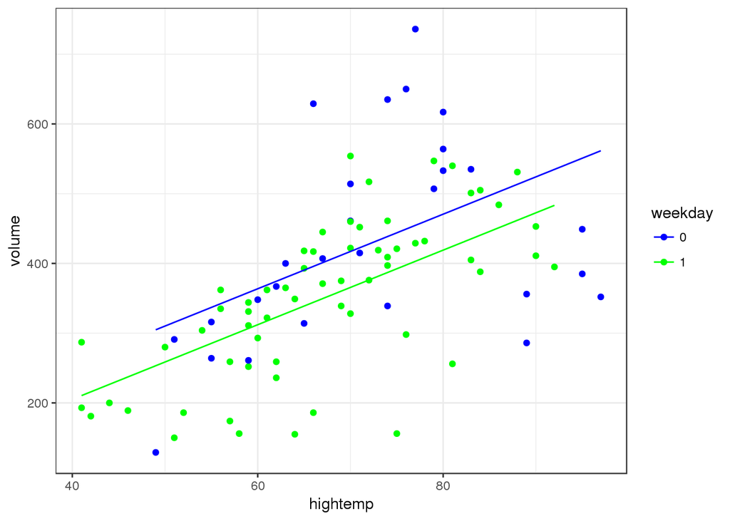

Figure 3: Visualization of parallel slopes for the rail trail data.

```r
DF4 <- augment(mod_parallel)
ggplot(data = DF4, aes(x = hightemp, y = volume, color = weekday)) +
  geom_point() +
  geom_line(aes(x = hightemp, y = .fitted)) +
  theme_bw() +
  scale_color_manual(values = c("blue", "green"))
```

A second approach:

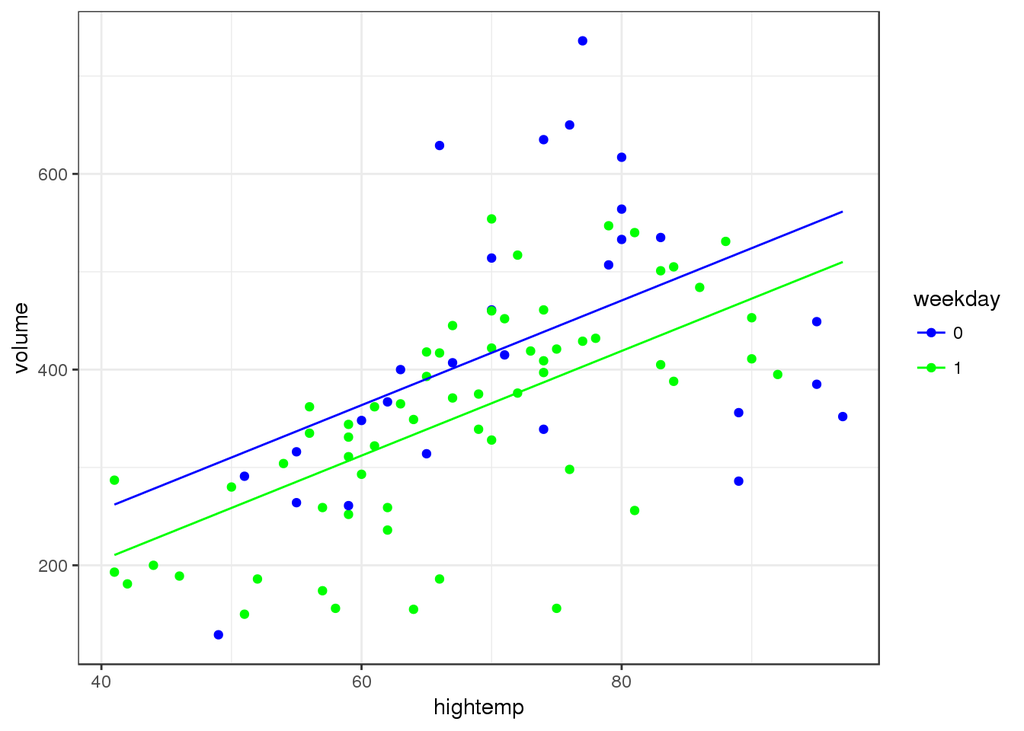

```r
DF4 <- augment(mod_parallel)
DF5 <- modelr::data_grid(DF4, hightemp, weekday) %>%
  modelr::gather_predictions(mod_parallel)
ggplot(data = DF4, aes(x = hightemp, y = volume, color = weekday)) +
  geom_point() +
  geom_line(data = DF5, aes(y = pred)) +
  theme_bw() +
  scale_color_manual(values = c("blue", "green"))
```

The approach the book takes (modified slightly):

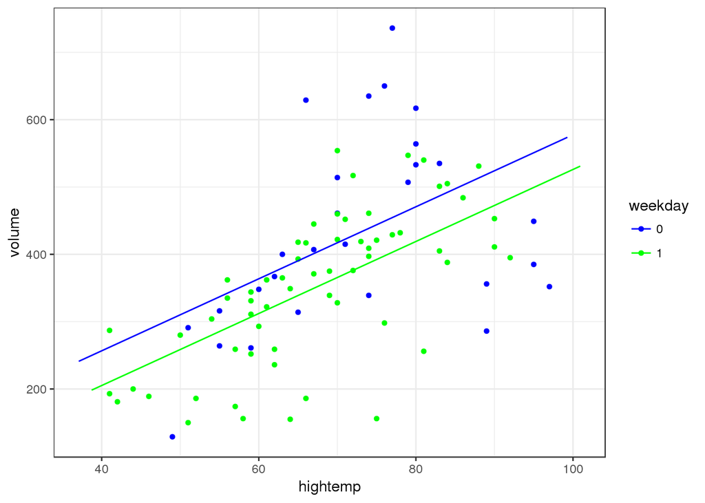

```r
plotModel(mod_parallel, system = "ggplot2") +
  theme_bw() +
  labs(color = "weekday") +
  scale_color_manual(values = c("blue", "green"))
```

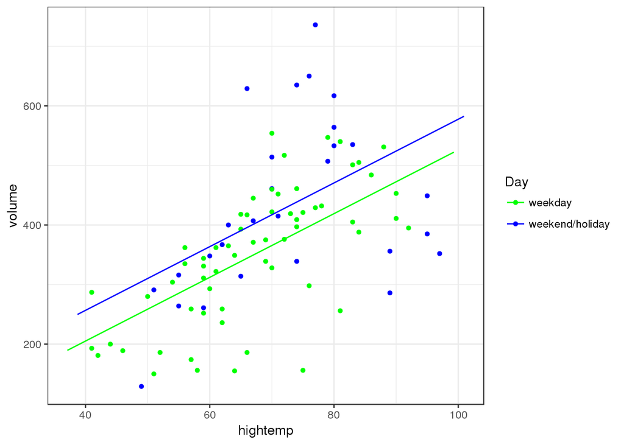

```r
plotModel(lm(volume ~ hightemp + day, data = RailTrail), system = "ggplot2") +
  theme_bw() +
  labs(color = "Day") +
  scale_color_manual(values = c("green", "blue"))
```

### A.2.2 Parallel planes: Multiple regression with a second quantitative variable

If $x_2$ is a quantitative variable, then we have:

$$\hat{y}=\hat{\beta}_0 + \hat{\beta}_1x_1 + \hat{\beta}_2x_2.$$

Notice that our model is no longer a line, rather it is a *plane* that exists in three dimensions.

Now suppose that we want to improve out model for ridership by considering not only the average temperature but also the amount of precipitation (rain or snow, measured in inches). We can do this in `R` by simply adding this variable to our regression model.

```r
mod_planes <- lm(volume ~ hightemp + precip, data = RailTrail)
coef(mod_planes)
```

```
(Intercept)    hightemp      precip
 -31.519670    6.117745 -153.260844
```

Note that the coefficient on `hightemp` (6.1177455 riders per degree) has changed from its value in the simple linear regression model (5.7018782 riders per degree). This is due to the moderating effect of precipitation. Our interpretation is that for each additional degree in temperature, we expect and additional 6.1177455 on the rail trail, after controlling for the amount of precipitation.

**Pro Tip**: Note that since the median precipitation on days when there was precipitation was only 0.15 inches, a predicted change for an additional inch may be misleading. It may be better to report a predicted difference of 0.15 inches or replace the continuous term in the model with a dichotomous indicator of any precipitation.

```r
RailTrail %>%
  mutate(Rain = ifelse(precip == 0.00, "No", "Yes")) %>%
  group_by(Rain) %>%
  summarize(Median = median(precip))
```

```
# A tibble: 2 x 2
  Rain  Median
  <chr>  <dbl>
1 No     0
2 Yes    0.150
```

As you can imagine, the effect of precipitation is strong — some people may be less likely to bike or walk in the rain. Thus, even after controlling for temperature, an inch of rainfall is associated with a drop in ridership of 153.2608435

If we added all three explanatory variables to the model we would have parallel planes.

```r
mod_p_planes <- lm(volume ~ hightemp + precip + weekday, data = RailTrail)
coef(mod_p_planes)
```

```
(Intercept)    hightemp      precip    weekday1
  19.318828    5.800674 -145.608985  -43.144313
```

### A.2.3 Non-parallel slopes: Multiple regression with interaction

let’s return to a model that includes `weekday` and `hightemp` as predictors. What if the parallel slopes model doesn’t fit well? Adding an additional term into the model can make it more flexible and allow there to be a different slope on the two different types of days:

$$\hat{y} = \hat{\beta}_0 + \hat{\beta}_1x_1 + \hat{\beta}_2x_2 + \hat{\beta}_3x_1x_2$$

We then have:

$$\begin{align*}
\text{For weekends, } \hat{y}|_{x_1, x_2 = 0} &= \hat{\beta}_0 + \hat{\beta}_1x_1\\
\text{For weekdays, } \hat{y}|_{x_1, x_2 = 1} &= \hat{\beta}_0 + \hat{\beta}_1x_1 + \hat{\beta}_2 \cdot 1 + \hat{\beta}_3 \cdot x_1\\
&= \left(\hat{\beta}_0 + \hat{\beta}_2 \right) + \left( \hat{\beta}_1 + \hat{\beta}_3 \right)x_1
\end{align*}$$

This is called an *interaction model* (see Figure 4). The predicted values of the model take the geometric shape of two non-parallel lines with different slopes.

```r
mod_interact <- lm(volume ~ hightemp + weekday + hightemp:weekday, data = RailTrail)
coef(mod_interact)
```

```
      (Intercept)          hightemp          weekday1 hightemp:weekday1
       135.152955          4.074701       -186.377005          1.905580
```

```r
summary(mod_interact)
```

```
Call:
lm(formula = volume ~ hightemp + weekday + hightemp:weekday,
    data = RailTrail)

Residuals:
     Min       1Q   Median       3Q      Max
-241.297  -62.478    8.907   55.772  287.095

Coefficients:
                  Estimate Std. Error t value Pr(>|t|)
(Intercept)        135.153    108.207   1.249  0.21505
hightemp             4.075      1.468   2.776  0.00676 **
weekday1          -186.377    129.248  -1.442  0.15293
hightemp:weekday1    1.906      1.796   1.061  0.29163
---
Signif. codes:  0 '***' 0.001 '**' 0.01 '*' 0.05 '.' 0.1 ' ' 1

Residual standard error: 102 on 86 degrees of freedom
Multiple R-squared:  0.3816,    Adjusted R-squared:  0.3601
F-statistic: 17.69 on 3 and 86 DF,  p-value: 4.957e-09
```

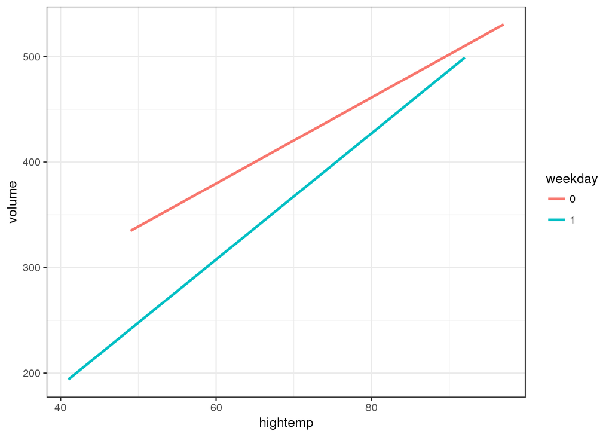

Figure 4: Visualization of interaction model for the rail trail data.

```r
ggplot(data = RailTrail, aes(x = hightemp, y = volume, color = weekday)) +
  geom_smooth(method = "lm", se = FALSE) +
  theme_bw()
```

The approach the book takes to show the *interaction model* is shown next.

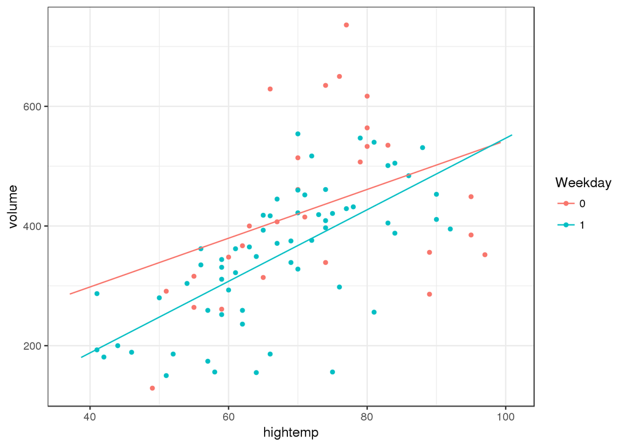

```r
plotModel(mod_interact, system = "ggplot2") +
  labs(color = "Weekday") +
  theme_bw()
```

We see that the slope on weekdays is about two riders (1.9055805) per degree higher that on weekends and holidays. This may indicate that trail users on weekends and holidays are less concerned about temperature than on weekdays.

### A.2.4 Modelling non-linear realtionships

A linear model with a single parameter fits well in many situations but is not appropriate in others. Consider modeling height (in centimeters) as a function of age (in years) using data from a subset of female subjects included in the National Health and Nutrition Examination Study (from the `NHANES` package) with a linear term. Another approach uses a *smoother* instead of a linear model. Unlike the straight line, the smoother can bend to better fit the points when modeling the functional form of a relationship (see Figure 5).

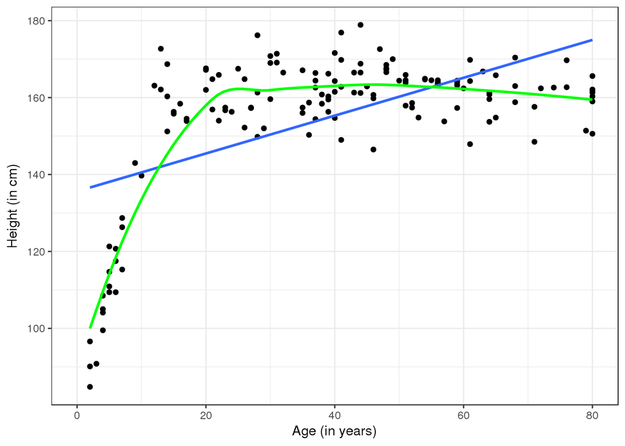

Figure 5: Scatterplot of height as a function of age with superimposed linear model (blue) and smoother (green).

```r
library(NHANES)
set.seed(21)
NHANES %>%
  sample(300) %>%
  filter(Gender == "female") %>%
  ggplot(aes(x = Age, y = Height)) +
  geom_point() +
  stat_smooth(method = "lm", se = FALSE) +
  stat_smooth(method = "loess", se = FALSE, color = "green") +
  labs(x = "Age (in years)", y = "Height (in cm)") +
  theme_bw()
```

The fit of the linear model in Figure 5 (denoted in blue) is poor: A straight line does not account for the dramatic increases in height during puberty to young adulthood or for the gradual decline in height for older subjects. The smoother (in green) does a much better job of describing the functional form.

The improved fit does come with a cost. Compare the results for linear and smoothed models in Figure 6. Here the functional form of the relationship between high temperature and volume of trail use is closer to linear (with some deviation for warmer temperatures).

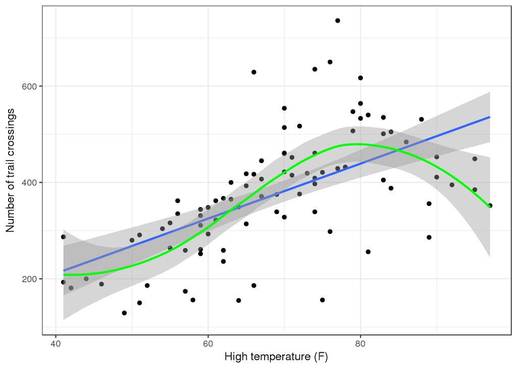

Figure 6: Scatterplot of volume as a function of high temperature with superimposed linear and smooth models for the rail trail data.

```r
ggplot(data = RailTrail, aes(x = hightemp, y = volume)) +
  geom_point() +
  stat_smooth(method = "lm") +
  stat_smooth(method = "loess", color = "green") +
  labs(y = "Number of trail crossings", x = "High temperature (F)") +
  theme_bw()
```

The width of the confidence bands for the smoother tend to be wider than that for the linear model. This is the cost of the additional flexibility in modeling. The other cost is interpretation: It is more complicated to explain the results from the smoother than to interpret a slope coefficient.

## A.3 Inference for regression

Thus far, we have fit several models and interpreted their estimated coefficients. However, with the exception of the confidence bands in Figure 6, we have only made statements about the estimated coefficients (i.e., the $\hat{\beta}$’s)—we have made no statements about the true coefficients (i.e., the $\beta$’s), the values of which of course remain unknown.

However, we can use our understanding of the $t$-distribution to make *inferences* about the true value of regression coefficients. In particular, we can test a hypothesis about $\beta_1$ (most commonly that it is equal to zero) and find a confidence interval (range of plausible values) for it.

```r
summary(mod_p_planes)
```

```
Call:
lm(formula = volume ~ hightemp + precip + weekday, data = RailTrail)

Residuals:
     Min       1Q   Median       3Q      Max
-255.225  -49.700    6.473   44.117  270.029

Coefficients:
             Estimate Std. Error t value Pr(>|t|)
(Intercept)   19.3188    60.3388   0.320 0.749614
hightemp       5.8007     0.7985   7.264 1.59e-10 ***
precip      -145.6090    38.8937  -3.744 0.000327 ***
weekday1     -43.1443    22.1942  -1.944 0.055172 .
---
Signif. codes:  0 '***' 0.001 '**' 0.01 '*' 0.05 '.' 0.1 ' ' 1

Residual standard error: 95.17 on 86 degrees of freedom
Multiple R-squared:  0.4613,    Adjusted R-squared:  0.4425
F-statistic: 24.55 on 3 and 86 DF,  p-value: 1.438e-11
```

In the output, the p-value that is associated with the `hightemp` coefficient is displayed as $1.5869578\times 10^{-10}$ (or nearly zero). That is the true coefficient ($\beta_1$) was in fact zero, then the probability of observing an association in ridership due to average temperature as alrge or larger than the one we actually observed in the data, after controlling for precipitation and day of the week, is essentially zero. This suggest that the hypothesis that $\beta_1$ was in fact zero is dubious based on these data. Perhaps there is a real association between ridership and average temperature.

**Pro Tip**: Very small p-values should be rounded to the nearest 0.0001. We suggest reporting this p-value as $p < 0.0001.$

```r
CIS <- confint(mod_p_planes, level = 0.95)
CIS
```

```
                  2.5 %      97.5 %
(Intercept) -100.630740 139.2683959
hightemp       4.213254   7.3880945
precip      -222.927105 -68.2908651
weekday1     -87.265016   0.9763902
```

Another way of thinking about this process is to form a confidence interval around our estimate of the slope coefficient $\hat{\beta}_1$. Here we can say with 95% confidence that the value of the true coefficient $\beta_1$ is between 4.2132536 and 7.3880945 riders per degree. That is this interval does not contain zero confirms the previous hypothesis test.

## A.4 Assumptions underlying regression

The inferences we made above were predicated upon our assumption that the slope follows a $t$-distribution. This follows from the assumption that the errors follow a normal distribution (with mean 0 and standard deviation $\sigma_{\epsilon}$, for some constant $\sigma_{\epsilon}$). Inferences from the model are only valid if the following assumptions hold:

**Linearity:** The functional form of the relationship between the predictors and the outcome follows a linear combination of regression parameters that are correctly specified (this assumption can be verified by bivariate graphical displays).

**Independence:** Are the errors uncorrelated? Or do they follow a pattern (perhaps over time or within clusters of subjects)?

**Normality of residuals:** Do the residuals follow a distribution that is approximately normal? This assumption can be verified using univariate displays.

**Equal variance of residuals:** Is the variance in the residuals constant across the explanatory variables (*homoscedastic errors*)? Or does the variance in the residuals depend on the value of one or more of the explanatory variables (*heteroscedastic errors*? This assumption can be verified using residual diagnostics.

These conditions are sometimes called the ``LINE’’ assumptions. All but the independence assumption can be assessed using diagnostic plots.

How might we asses the `mod_p_planes` model? Figure 7 displays a scatterplot of residuals versus fitted (predicted) values. As we observed in Figure 6, the number of crossings does not increase as much for warm temperatures as it does for more moderate ones. We may need to consider a more sophisticated model with a more complex model for temperature.

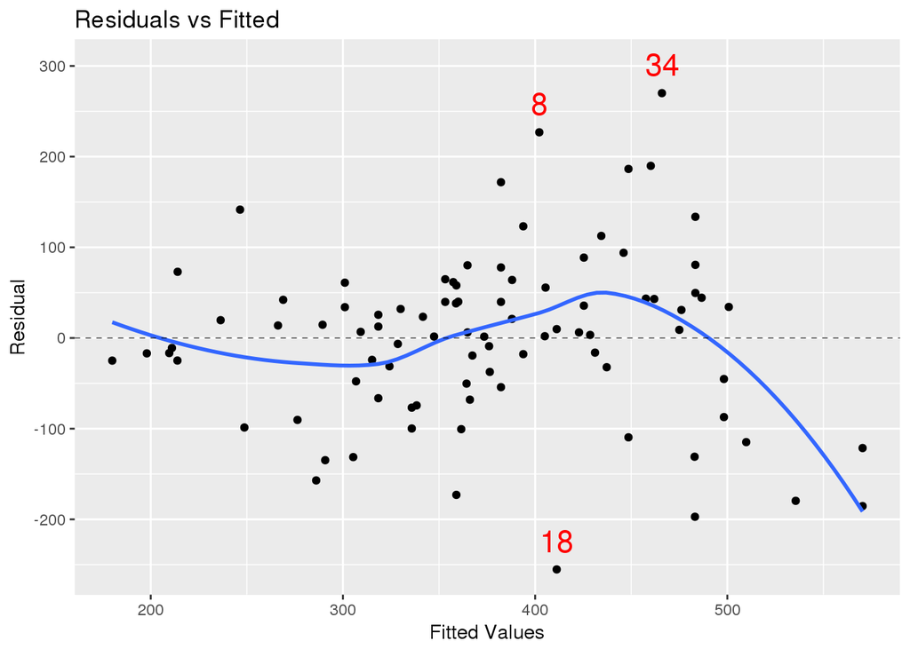

Figure 7: Assessing linearity using a scatterplot of residuals versus fitted (predicted) values.

```r
mplot(mod_p_planes, which = 1, system = "ggplot2")
```

Figure 8 display the quantile-quantile plot for the residuals for the regression model. The plot deviates from the straight line: This indicates that the residuals have heavier tails than a normal distribution.

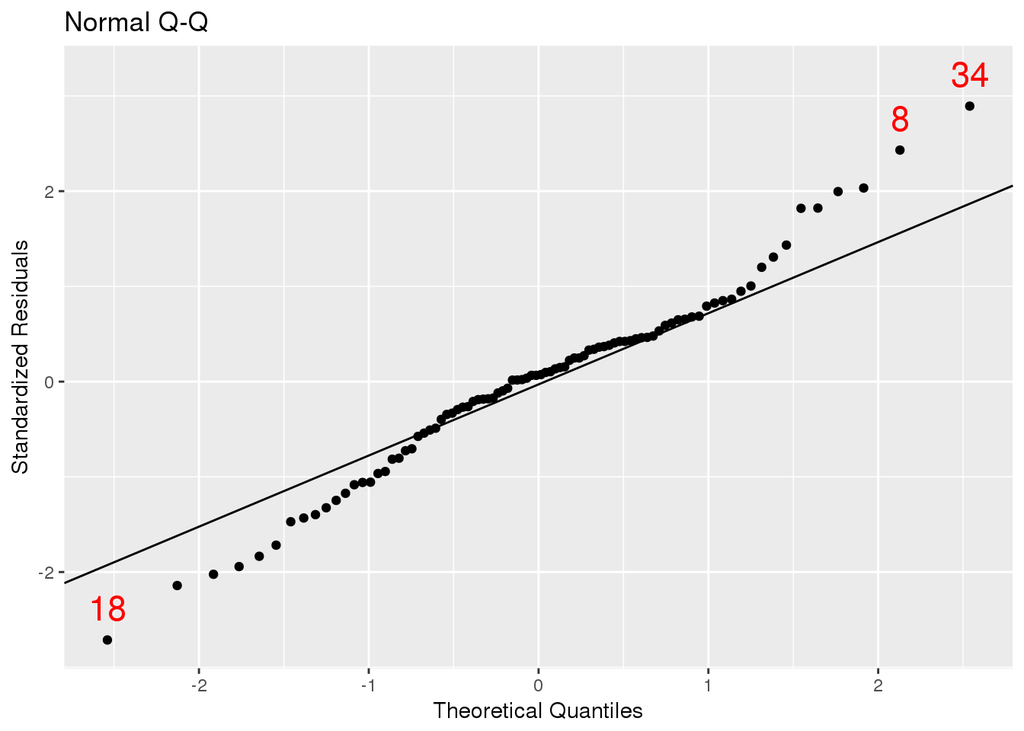

Figure 8: Assessing normality assumption using a Q-Q plot.

```r
mplot(mod_p_planes, which = 2, system = "ggplot2")
```

Figure 9 displays the scale-location plot for the residuals from the model: The results indicate that there is evidence of heteroscedasticity (the variance of the residuals increases as a function of predicted value).

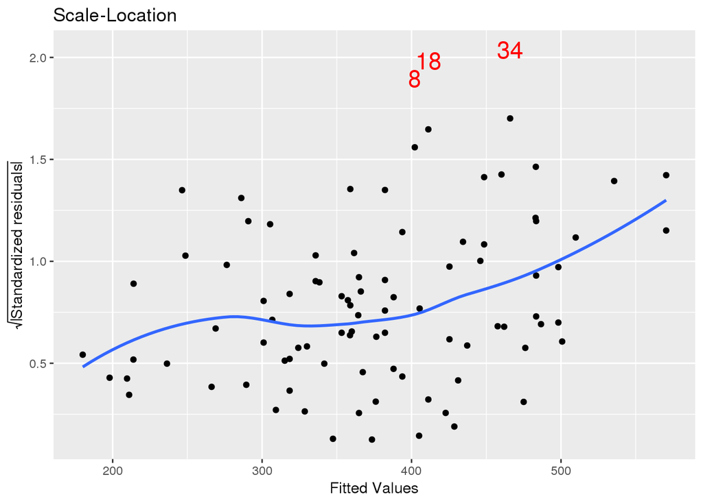

Figure 9: Assessing equal variance using a scale-location plot.

```r
mplot(mod_p_planes, which = 3, system = "ggplot2")
```

When performing model diagnostics, it is important to identify any outliers and understand their role in determining the regression coefficients.

- An *outlier* is an observation that doesn’t seem to fit the general pattern of the data.
- An observation with an extreme value of the explanatory variable is a point of high *leverage*.
- A high leverage point that exerts disproportionate influence on the slope of the regression line is an *influential point*.

Figure 10 displays the values for Cook’s distance (a common measure of influential points in a regression model).

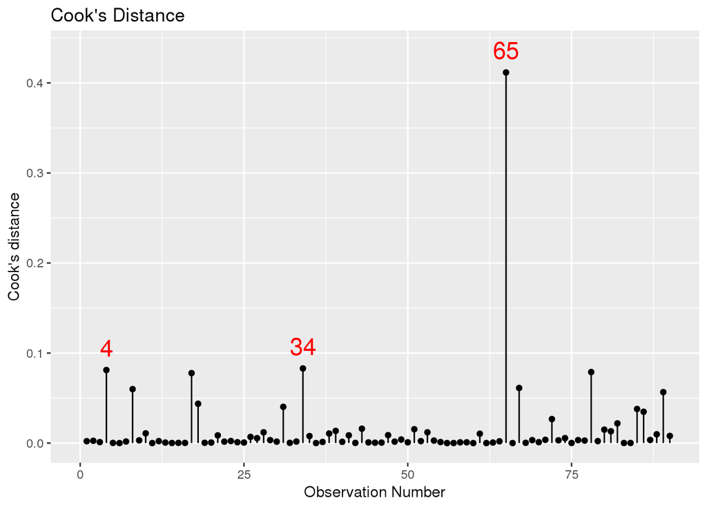

Figure 10: Cook’s distance for rail trail model

```r
mplot(mod_p_planes, which = 4, system = "ggplot2")
```

We use the `augment()` function from the `broom` package to calculate the value of this statistic and identify the most extreme Cook’s distance.

```r
library(broom)
augment(mod_p_planes) %>%
  filter(.cooksd > 0.4)
```

```
  volume hightemp precip weekday  .fitted  .se.fit   .resid      .hat
1    388       84   1.49       1 246.4737 54.84409 141.5263 0.3321057
    .sigma   .cooksd .std.resid
1 93.86542 0.4116154   1.819665
```

The outlier corresponds to a day with nearly one and a half inches of rain (the most recorded in the dataset) and a high temperature of 84 degrees.

## A.5 Logistic regression

Our previous examples had a quantitative (or continuous) outcomes. What happens when we are interested in modeling a dichotomous outcome? For example, we might model the probability of developing diabetes as a function of age and BMI (we explored this question further in Chapter 8). Figure 11 displays the scatterplot of diabetes status as a function of age, while Figure 12 displays the scatterplot of diabetes as a function of BMI (body mass index). Note that each subject can either have diabetes or not, so all of the points are displayed at zero or one on the $y$-axis.

```r
NHANES <- NHANES %>%
  mutate(has_diabetes = as.numeric(Diabetes == "Yes"))
log_plot <- ggplot(data = NHANES, aes(x = Age, y = has_diabetes)) +
  geom_jitter(alpha = 0.1, height = 0.05) +
  geom_smooth(method = "glm", method.args = list(family = "binomial"))
```

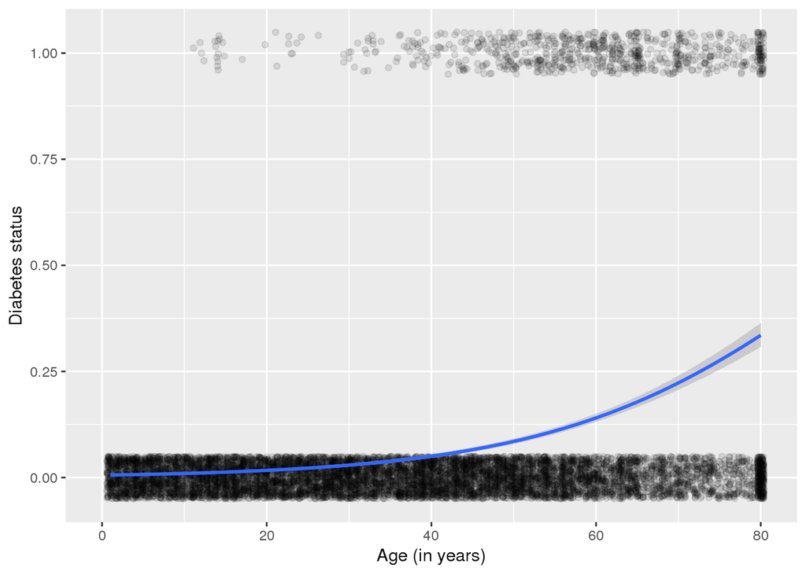

Figure 11: Scatterplot of diabetes as a function of age with superimposed smoother.

```r
log_plot +
  labs(x = "Age (in years)", y = "Diabetes status")
```

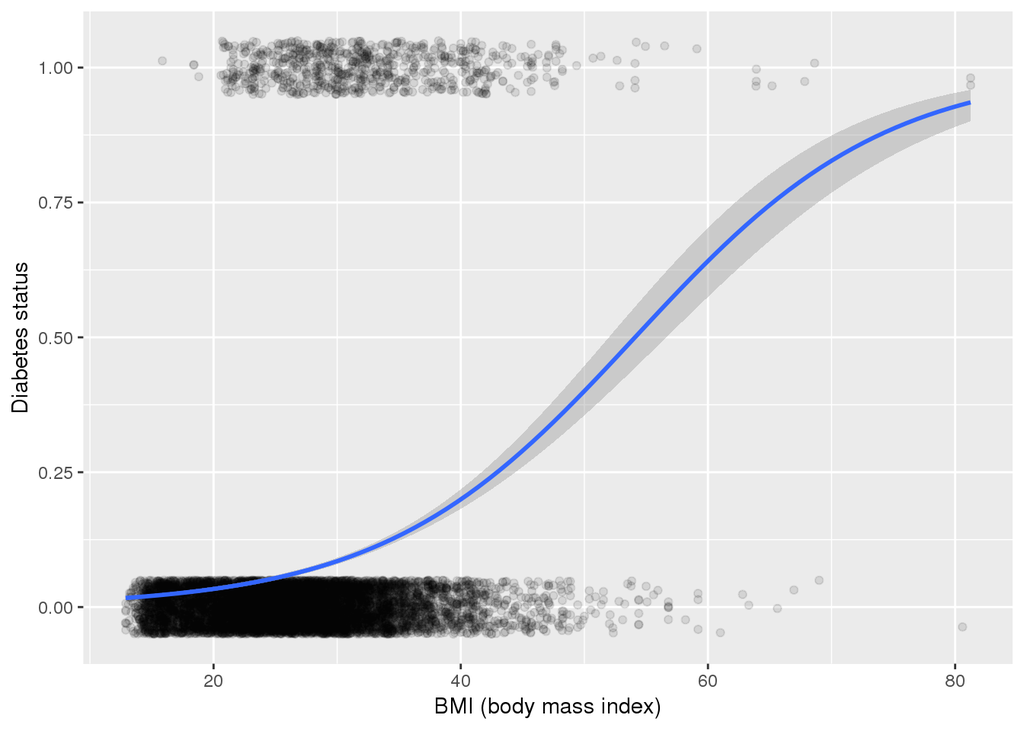

Figure 12: Scatterplot of diabetes as a function of BMI with superimposed smoother.

```r
log_plot +
  aes(x = BMI) +
  labs(x = "BMI (body mass index)", y = "Diabetes status")
```

Which variable is more important: `Age` or `BMI`? We can use a logistic regression model to model the probability of diabetes as a function of both predictors.

```r
logreg <- glm(has_diabetes ~ BMI + Age, family = "binomial", data = NHANES)
summary(logreg)
```

```
Call:
glm(formula = has_diabetes ~ BMI + Age, family = "binomial",
    data = NHANES)

Deviance Residuals:
    Min       1Q   Median       3Q      Max
-1.9207  -0.4084  -0.2307  -0.1026   3.2685

Coefficients:
             Estimate Std. Error z value Pr(>|z|)
(Intercept) -8.080292   0.244447  -33.05   <2e-16 ***
BMI          0.094325   0.005519   17.09   <2e-16 ***
Age          0.057278   0.002487   23.03   <2e-16 ***
---
Signif. codes:  0 '***' 0.001 '**' 0.01 '*' 0.05 '.' 0.1 ' ' 1

(Dispersion parameter for binomial family taken to be 1)

    Null deviance: 5263.8  on 9628  degrees of freedom
Residual deviance: 4146.0  on 9626  degrees of freedom
  (371 observations deleted due to missingness)
AIC: 4152

Number of Fisher Scoring iterations: 7
```

The answer if that both are important (both are statistically significant predictors). To interpret the findings, we might consider a visual display of predicted probabilities as displayed in Figure 13 (compare with Figure 11).

```r
ages <- range(~Age, data = NHANES)
bmis <- range(~BMI, data = NHANES, na.rm = TRUE)
res <- 100
fake_grid <- expand.grid(
  Age = seq(from = ages[1], to = ages[2], length.out = res),
  BMI = seq(from = bmis[1], to = bmis[2], length.out = res)
)
y_hats <- fake_grid %>%
  mutate(y_hat = predict(logreg, newdata = ., type = "response"))
```

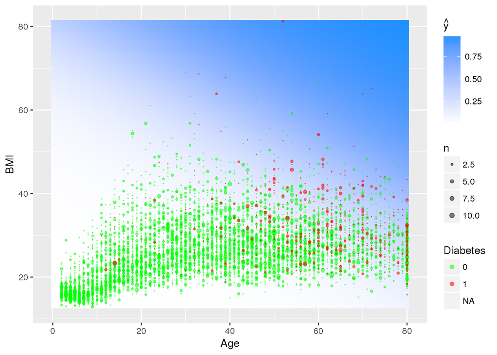

Figure 13: Predicted probabilities for diabetes as a function of BMI and age.

```r
ggplot(data = NHANES, aes(x = Age, y = BMI)) +
  geom_tile(data = y_hats, aes(fill = y_hat), color = NA) +
  geom_count(aes(color = as.factor(has_diabetes)), alpha = 0.5) +
  scale_fill_gradient(low = "white", high = "dodgerblue") +
  scale_color_manual("Diabetes", values = c("green", "red")) +
  scale_size(range = c(0, 2)) +
  labs(fill = expression(hat(y)))
```

We see that very few young adults have diabetes, even if they have moderately high BMI scores. As we look at older subjects while holding BMI fixed, the probability of diabetes increases.

## A.6 Further resources

Regression is described in many books. An introduction is found in most introductory statistics textbooks, including *Open Intro Statistics* by Diez, Barr, and Çetinkaya-Rundel (2015). For a deeper but still accessible treatment, we suggest Cannon et al. (2012). Modern texts by James et al. (2017) and Hastie, Tibshirani, and Friedman (2016) also cover regression form a modeling and machine learning perspective. Hoaglin (2016) details how conditional regression parameters should be interpreted. Cook and Weisberg (1983) reviews regression diagnostics. An accessible introduction to smoothing can be found in Ruppert, Wand, and Carroll (2003).

## References

Cannon, Ann R., George W. Cobb, Bradley A. Hartlaub, Julie M. Legler, Robin H. Lock, Thomas L. Moore, Allan J. Rossman, and Jeffrey A. Witmer. 2012. *STAT2: With Premium Access Card*. Student edition. New York: W. H. Freeman.

Cook, R. Dennis, and Sanford Weisberg. 1983. *Residuals and Influence in Regression*. 1st edition. New York: Chapman; Hall/CRC.

Diez, David M., Christopher D. Barr, and Mine Çetinkaya-Rundel. 2015. *OpenIntro Statistics, FULL COLOR Hardcover*. 3rd edition. OpenIntro, Inc.

Hastie, Trevor, Robert Tibshirani, and Jerome Friedman. 2016. *The Elements of Statistical Learning: Data Mining, Inference, and Prediction, Second Edition*. 2nd edition. New York, NY: Springer.

Hoaglin, David C. 2016. “Regressions Are Commonly Misinterpreted.” *Stata Journal* 16 (1): 5–22. https://ideas.repec.org/a/tsj/stataj/v16y2016i1p5-22.html.

James, Gareth, Daniela Witten, Trevor Hastie, and Robert Tibshirani. 2017. *An Introduction to Statistical Learning: With Applications in R*. 1st ed. 2013, Corr. 7th printing 2017 edition. New York: Springer.

Ruppert, David, M. P. Wand, and R. J. Carroll. 2003. *Semiparametric Regression*. 1 edition. Cambridge ; New York: Cambridge University Press.